# StudentsClimateChangeRF

Shealy and Katz

5/9/2020

Script for creating random forests for Q5 and Q16

Create a new dataframe for the random forest work

```
## # A tibble: 4,605 x 20
##      Q1a   Q1b   Q1c   Q1d   Q1e   Q1f   Q1g   Q1h   Q1i   Q1j   Q1k   Q1l   Q1m
##    <dbl> <dbl> <dbl> <dbl> <dbl> <dbl> <dbl> <dbl> <dbl> <dbl> <dbl> <dbl> <dbl>
##  1    NA    NA    NA    NA    NA    NA     2     1    NA    NA    NA    NA    NA
##  2    NA    NA    NA    NA    NA    NA     2     1    NA    NA    NA    NA    NA
##  3    NA    NA    NA    NA    NA    NA     3     1    NA    NA    NA    NA    NA
##  4    NA    NA    NA    NA    NA    NA    NA     1    NA    NA    NA    NA    NA
##  5    NA    NA    NA    NA    NA    NA    NA     1    NA    NA    NA    NA    NA
##  6    NA    NA    NA    NA    NA    NA     1     2    NA    NA    NA    NA    NA
##  7    NA    NA    NA    NA     3    NA     2     1    NA    NA    NA    NA    NA
##  8    NA    NA    NA    NA    NA    NA     3     1    NA    NA    NA    NA    NA
##  9    NA    NA     2    NA    NA    NA     3     1    NA    NA    NA    NA    NA
## 10    NA    NA    NA    NA    NA    NA    NA     1    NA     3    NA    NA    NA
## # ... with 4,595 more rows, and 7 more variables: Q1n <dbl>, Q1o <dbl>,
## #   Q1p <dbl>, Q1q <dbl>, Q1r <dbl>, Q1s <dbl>, Q1t <dbl>
```

```
## Note: Using an external vector in selections is ambiguous.
## i Use `all_of(Q1_vars)` instead of `Q1_vars` to silence this message.
## i See <https://tidyselect.r-lib.org/reference/faq-external-vector.html>.
```

```
## # A tibble: 4,605 x 20
##      Q1a   Q1b   Q1c   Q1d   Q1e   Q1f   Q1g   Q1h   Q1i   Q1j   Q1k   Q1l   Q1m
##    <dbl> <dbl> <dbl> <dbl> <dbl> <dbl> <dbl> <dbl> <dbl> <dbl> <dbl> <dbl> <dbl>
##  1     0     0     0     0     0     0     2     1     0     0     0     0     0
##  2     0     0     0     0     0     0     2     1     0     0     0     0     0
##  3     0     0     0     0     0     0     3     1     0     0     0     0     0
##  4     0     0     0     0     0     0     0     1     0     0     0     0     0
##  5     0     0     0     0     0     0     0     1     0     0     0     0     0
##  6     0     0     0     0     0     0     1     2     0     0     0     0     0
##  7     0     0     0     0     3     0     2     1     0     0     0     0     0
##  8     0     0     0     0     0     0     3     1     0     0     0     0     0
##  9     0     0     2     0     0     0     3     1     0     0     0     0     0
## 10     0     0     0     0     0     0     0     1     0     3     0     0     0
## # ... with 4,595 more rows, and 7 more variables: Q1n <dbl>, Q1o <dbl>,
## #   Q1p <dbl>, Q1q <dbl>, Q1r <dbl>, Q1s <dbl>, Q1t <dbl>
```

```
## # A tibble: 4,605 x 7
##      Q3a   Q3b   Q3c   Q3d   Q3e   Q3f   Q3g
##    <dbl> <dbl> <dbl> <dbl> <dbl> <dbl> <dbl>
##  1    NA    NA    NA    NA    NA    NA    NA
##  2    NA    NA    NA    NA    NA    NA    NA
##  3    NA     1     1    NA    NA    NA    NA
##  4    NA     1    NA    NA    NA    NA    NA
##  5    NA     1    NA    NA    NA    NA    NA
##  6     1    NA    NA     1    NA    NA    NA
##  7    NA     1     1    NA    NA    NA    NA
##  8     1     1     1    NA    NA    NA    NA
##  9    NA     1    NA    NA    NA    NA    NA
## 10    NA    NA    NA    NA    NA    NA    NA
## # ... with 4,595 more rows
```

```
## Note: Using an external vector in selections is ambiguous.
## i Use `all_of(Q3_vars)` instead of `Q3_vars` to silence this message.
## i See <https://tidyselect.r-lib.org/reference/faq-external-vector.html>.
```

```
## # A tibble: 4,605 x 7
##      Q3a   Q3b   Q3c   Q3d   Q3e   Q3f   Q3g
##    <dbl> <dbl> <dbl> <dbl> <dbl> <dbl> <dbl>
##  1     0     0     0     0     0     0     0
##  2     0     0     0     0     0     0     0
##  3     0     1     1     0     0     0     0
##  4     0     1     0     0     0     0     0
##  5     0     1     0     0     0     0     0
##  6     1     0     0     1     0     0     0
##  7     0     1     1     0     0     0     0
##  8     1     1     1     0     0     0     0
##  9     0     1     0     0     0     0     0
## 10     0     0     0     0     0     0     0
## # ... with 4,595 more rows
```

```
## # A tibble: 4,605 x 10
##      Q5a   Q5b   Q5c   Q5d   Q5e   Q5f   Q5g   Q5h   Q5i   Q5j
##    <dbl> <dbl> <dbl> <dbl> <dbl> <dbl> <dbl> <dbl> <dbl> <dbl>
##  1     1     0     0     0     1     0     0     0     0     0
##  2     0     0     0     0     0     0     0     1     0     0
##  3     0     0     0     0     0     0     0     1     0     0
##  4     1     0     0     0     0     0     0     0     0     0
##  5     1     0     0     0     0     0     0     0     0     0
##  6     0     0     0     1     0     0     0     1     0     1
##  7     1     0     1     0     1     0     1     1     0     0
##  8     1     1     0     1     1     1     1     1     0     1
##  9     0     1     0     0     0     0     0     0     0     1
## 10     1     0     0     0     0     0     0     0     0     0
## # ... with 4,595 more rows
```

```
## # A tibble: 4,605 x 22
##      Q7a Q7b     Q7c   Q7d   Q7e   Q7f   Q7g   Q7h Q7i   Q7j   Q7k   Q7l   Q7m
##    <dbl> <chr> <dbl> <dbl> <dbl> <dbl> <dbl> <dbl> <chr> <chr> <chr> <chr> <chr>
##  1     2 <NA>     NA    NA    NA    NA    NA    NA <NA>  <NA>  <NA>  <NA>  <NA>
##  2     2 3         4     4     4     4     4     4 4     4     4     4     4
##  3    NA <NA>     NA    NA    NA    NA    NA    NA <NA>  <NA>  <NA>  <NA>  <NA>
##  4     1 1        NA    NA    NA    NA    NA    NA <NA>  <NA>  <NA>  <NA>  <NA>
##  5    NA <NA>     NA    NA    NA    NA    NA    NA <NA>  <NA>  <NA>  <NA>  <NA>
##  6     2 1         3     3    NA    NA    NA    NA <NA>  <NA>  <NA>  <NA>  <NA>
##  7     1 3         2    NA     1     3     3     1 2     4     1     2     3
##  8     2 2         3    NA     3     3     3    NA 3     1     <NA>  <NA>  3
##  9    NA <NA>     NA    NA    NA    NA    NA    NA <NA>  <NA>  <NA>  <NA>  <NA>
## 10   123 123       4     4     4    NA    NA    NA <NA>  123   123   <NA>  <NA>
## # ... with 4,595 more rows, and 9 more variables: Q7n <chr>, Q7o <chr>,
## #   Q7p <chr>, Q7q <chr>, Q7r <chr>, Q7s <chr>, Q7t <chr>, Q7u <chr>, Q7v <chr>
```

```
## Note: Using an external vector in selections is ambiguous.
## i Use `all_of(Q7_vars)` instead of `Q7_vars` to silence this message.
## i See <https://tidyselect.r-lib.org/reference/faq-external-vector.html>.
```

```
## # A tibble: 4,605 x 22
##      Q7a Q7b     Q7c   Q7d   Q7e   Q7f   Q7g   Q7h Q7i   Q7j   Q7k   Q7l   Q7m
##    <dbl> <chr> <dbl> <dbl> <dbl> <dbl> <dbl> <dbl> <chr> <chr> <chr> <chr> <chr>
##  1     2 0         0     0     0     0     0     0 0     0     0     0     0
##  2     2 3         4     4     4     4     4     4 4     4     4     4     4
##  3     0 0         0     0     0     0     0     0 0     0     0     0     0
##  4     1 1         0     0     0     0     0     0 0     0     0     0     0
##  5     0 0         0     0     0     0     0     0 0     0     0     0     0
##  6     2 1         3     3     0     0     0     0 0     0     0     0     0
##  7     1 3         2     0     1     3     3     1 2     4     1     2     3
##  8     2 2         3     0     3     3     3     0 3     1     0     0     3
##  9     0 0         0     0     0     0     0     0 0     0     0     0     0
## 10   123 123       4     4     4     0     0     0 0     123   123   0     0
## # ... with 4,595 more rows, and 9 more variables: Q7n <chr>, Q7o <chr>,
## #   Q7p <chr>, Q7q <chr>, Q7r <chr>, Q7s <chr>, Q7t <chr>, Q7u <chr>, Q7v <chr>
```

```
## # A tibble: 4,605 x 9
##     Q35a  Q35b  Q35c  Q35d  Q35e  Q35f  Q35g  Q35h  Q35i
##    <dbl> <dbl> <dbl> <dbl> <dbl> <dbl> <dbl> <dbl> <dbl>
##  1     1     1    NA    NA    NA     1    NA     1     1
##  2    NA    NA    NA    NA    NA    NA    NA    NA    NA
##  3    NA    NA    NA     1    NA    NA    NA    NA    NA
##  4    NA    NA    NA    NA    NA    NA    NA    NA    NA
##  5    NA    NA    NA    NA    NA    NA    NA    NA    NA
##  6    NA    NA    NA    NA    NA    NA    NA    NA    NA
##  7    NA    NA    NA    NA    NA    NA    NA    NA    NA
##  8    NA    NA    NA    NA    NA    NA    NA    NA    NA
##  9    NA    NA    NA    NA    NA    NA    NA    NA    NA
## 10    NA    NA    NA    NA    NA    NA    NA    NA    NA
## # ... with 4,595 more rows
```

```
## Note: Using an external vector in selections is ambiguous.
## i Use `all_of(Q35_vars)` instead of `Q35_vars` to silence this message.
## i See <https://tidyselect.r-lib.org/reference/faq-external-vector.html>.
```

```
## # A tibble: 4,605 x 9
##     Q35a  Q35b  Q35c  Q35d  Q35e  Q35f  Q35g  Q35h  Q35i
##    <dbl> <dbl> <dbl> <dbl> <dbl> <dbl> <dbl> <dbl> <dbl>
##  1     1     1     0     0     0     1     0     1     1
##  2     0     0     0     0     0     0     0     0     0
##  3     0     0     0     1     0     0     0     0     0
##  4     0     0     0     0     0     0     0     0     0
##  5     0     0     0     0     0     0     0     0     0
##  6     0     0     0     0     0     0     0     0     0
##  7     0     0     0     0     0     0     0     0     0
##  8     0     0     0     0     0     0     0     0     0
##  9     0     0     0     0     0     0     0     0     0
## 10     0     0     0     0     0     0     0     0     0
## # ... with 4,595 more rows
```

```
## # A tibble: 4,605 x 9
##     Q39a  Q39b  Q39c  Q39d  Q39e  Q39f  Q39g  Q39h  Q39i
##    <dbl> <dbl> <dbl> <dbl> <dbl> <dbl> <dbl> <dbl> <dbl>
##  1    NA    NA    NA     1    NA    NA    NA    NA    NA
##  2    NA    NA    NA    NA    NA    NA    NA    NA    NA
##  3    NA     1    NA    NA    NA    NA    NA    NA    NA
##  4    NA    NA    NA    NA    NA    NA    NA    NA    NA
##  5    NA    NA    NA    NA    NA    NA    NA    NA    NA
##  6    NA    NA    NA    NA    NA    NA    NA    NA    NA
##  7    NA    NA    NA    NA    NA    NA    NA    NA    NA
##  8    NA    NA    NA    NA    NA    NA    NA    NA    NA
##  9    NA    NA    NA    NA    NA    NA    NA    NA    NA
## 10    NA    NA    NA    NA    NA    NA    NA    NA    NA
## # ... with 4,595 more rows
```

```
## Note: Using an external vector in selections is ambiguous.
## i Use `all_of(Q39_vars)` instead of `Q39_vars` to silence this message.
## i See <https://tidyselect.r-lib.org/reference/faq-external-vector.html>.
```

```
## # A tibble: 4,605 x 9
##     Q39a  Q39b  Q39c  Q39d  Q39e  Q39f  Q39g  Q39h  Q39i
##    <dbl> <dbl> <dbl> <dbl> <dbl> <dbl> <dbl> <dbl> <dbl>
##  1     0     0     0     1     0     0     0     0     0
##  2     0     0     0     0     0     0     0     0     0
##  3     0     1     0     0     0     0     0     0     0
##  4     0     0     0     0     0     0     0     0     0
##  5     0     0     0     0     0     0     0     0     0
##  6     0     0     0     0     0     0     0     0     0
##  7     0     0     0     0     0     0     0     0     0
##  8     0     0     0     0     0     0     0     0     0
##  9     0     0     0     0     0     0     0     0     0
## 10     0     0     0     0     0     0     0     0     0
## # ... with 4,595 more rows
```

```
## # A tibble: 4,605 x 12
##     Q28a  Q28b  Q28c  Q28d  Q28e  Q28f  Q28g  Q28h  Q28i  Q28j  Q28k  Q28l
##    <dbl> <dbl> <dbl> <dbl> <dbl> <dbl> <dbl> <dbl> <dbl> <dbl> <dbl> <dbl>
##  1     3     3     3     3     3     3     3     3     3     3     3     3
##  2     4     2     0     0     4     4     4     4     4     0     4     0
##  3    NA    NA    NA    NA    NA    NA    NA    NA    NA    NA    NA    NA
##  4    NA    NA    NA    NA    NA    NA    NA    NA    NA    NA    NA    NA
##  5    NA    NA    NA    NA    NA    NA    NA    NA    NA    NA    NA    NA
##  6    NA    NA    NA    NA    NA    NA    NA    NA    NA    NA    NA    NA
##  7    NA    NA    NA    NA    NA    NA    NA    NA    NA    NA    NA    NA
##  8    NA    NA    NA    NA    NA    NA    NA    NA    NA    NA    NA    NA
##  9    NA    NA    NA    NA    NA    NA    NA    NA    NA    NA    NA    NA
## 10    NA    NA    NA    NA    NA    NA    NA    NA    NA    NA    NA    NA
## # ... with 4,595 more rows
```

```
## Note: Using an external vector in selections is ambiguous.
## i Use `all_of(Q28_vars)` instead of `Q28_vars` to silence this message.
## i See <https://tidyselect.r-lib.org/reference/faq-external-vector.html>.
```

```
## # A tibble: 3,486 x 12
##     Q28a  Q28b  Q28c  Q28d  Q28e  Q28f  Q28g  Q28h  Q28i  Q28j  Q28k  Q28l
##    <dbl> <dbl> <dbl> <dbl> <dbl> <dbl> <dbl> <dbl> <dbl> <dbl> <dbl> <dbl>
##  1     3     3     3     3     3     3     3     3     3     3     3     3
##  2     4     2     0     0     4     4     4     4     4     0     4     0
##  3     4     4     1     1     3     4     3     3     3     1     4     0
##  4     4     4     0     0     4     4     4     4     4     4     4     4
##  5     4     4     3     3     4     4     4     3     4     3     4     3
##  6     4     4     2     4     4     4     4     4     4     3     4     2
##  7     4     4     1     1     4     3     2     3     3     1     2     1
##  8     4     4     0     1     4     4     4     4     3     4     4     1
##  9     3     0     0     0     0     3     3     2     0     0     0     0
## 10     3     2     0     0     0     3     3     3     3     0     3     1
## # ... with 3,476 more rows
```

```
## Note: Using an external vector in selections is ambiguous.
## i Use `all_of(Q16_vars)` instead of `Q16_vars` to silence this message.
## i See <https://tidyselect.r-lib.org/reference/faq-external-vector.html>.
```

Turn the variables into factors

Remove columns that will not feed into the random forest algorithm

Remove observations with more than 10% obs missing

Create random forest for Q5d with tidymodels framework

```
##
##    0    1
## 2155 1097
```

```
##
##    0    1
## 1617  823
```

Create the random forest model specification

```
## Random Forest Model Specification (classification)
##
## Computational engine: ranger
```

```
## tibble [4,605 x 8] (S3: spec_tbl_df/tbl_df/tbl/data.frame)
##  $ Q5d      : Factor w/ 2 levels "0","1": 1 1 1 1 1 2 1 2 1 1 ...
##  $ Q20d     : num [1:4605] 2 4 NA NA NA NA NA NA NA NA ...
##  $ Q16abc   : num [1:4605] 9 9 6 NA NA NA 9 6 NA NA ...
##  $ Q18c     : num [1:4605] 2 4 2 NA NA NA 1 2 NA NA ...
##  $ Q18k     : num [1:4605] 2 4 2 NA NA NA 3 2 NA NA ...
##  $ Q28afghik: num [1:4605] 18 24 NA NA NA NA NA NA NA NA ...
##  $ Q28b     : num [1:4605] 3 2 NA NA NA NA NA NA NA NA ...
##  $ Q28cdej  : num [1:4605] 12 4 NA NA NA NA NA NA NA NA ...
```

```
## tibble [3,454 x 8] (S3: tbl_df/tbl/data.frame)
##  $ Q5d      : Factor w/ 2 levels "0","1": 1 1 1 1 1 1 1 2 1 1 ...
##  $ Q20d     : num [1:3454] 2 4 NA NA NA NA NA 3 NA 3 ...
##  $ Q16abc   : num [1:3454] 9 9 6 NA NA 9 NA 7 NA 12 ...
##  $ Q18c     : num [1:3454] 2 4 2 NA NA 1 NA 4 NA 3 ...
##  $ Q18k     : num [1:3454] 2 4 2 NA NA 3 NA 3 NA 3 ...
##  $ Q28afghik: num [1:3454] 18 24 NA NA NA NA NA 21 NA 24 ...
##  $ Q28b     : num [1:3454] 3 2 NA NA NA NA NA 4 NA 4 ...
##  $ Q28cdej  : num [1:3454] 12 4 NA NA NA NA NA 6 NA 8 ...
```

```
## Data Recipe
##
## Inputs:
##
##       role #variables
##    outcome          1
##  predictor          7
##
## Training data contained 3454 data points and 966 incomplete rows.
##
## Operations:
##
## Zero variance filter removed no terms [trained]
## Centering and scaling for Q20d, Q16abc, Q18c, Q18k, Q28afghik, ... [trained]
```

Create the training data with all the preprocessing and then specify the model

```
## parsnip model object
##
## Fit time:  40ms
##
## Call:  stats::glm(formula = formula, family = stats::binomial, data = data)
##
## Coefficients:
## (Intercept)         Q20d       Q16abc         Q18c         Q18k    Q28afghik
##    -1.03311      0.44425      0.56490      0.37095      0.29744      0.40267
##        Q28b      Q28cdej
##     0.11532     -0.08787
##
## Degrees of Freedom: 2487 Total (i.e. Null);  2480 Residual
##   (966 observations deleted due to missingness)
## Null Deviance:       3189
## Residual Deviance: 2473  AIC: 2489
```

old school model creation

Run ANOVA on model

```
## Analysis of Deviance Table
##
## Model: binomial, link: logit
##
## Response: Q5d
##
## Terms added sequentially (first to last)
##
##
##           Df Deviance Resid. Df Resid. Dev  Pr(>Chi)
## NULL                       2487     3188.6
## Q20d       1   430.81      2486     2757.8 < 2.2e-16 ***
## Q16abc     1   158.55      2485     2599.2 < 2.2e-16 ***
## Q18c       1    58.27      2484     2540.9 2.280e-14 ***
## Q18k       1    29.97      2483     2511.0 4.379e-08 ***
## Q28afghik  1    34.20      2482     2476.8 4.986e-09 ***
## Q28b       1     1.49      2481     2475.3    0.2219
## Q28cdej    1     1.86      2480     2473.4    0.1723
## ---
## Signif. codes:  0 '***' 0.001 '**' 0.01 '*' 0.05 '.' 0.1 ' ' 1
```

Analysis of Deviance Table

|  | Df | Deviance | Resid. Df | Resid. Dev | Pr(>Chi) |
| --- | --- | --- | --- | --- | --- |
| **NULL** | NA | NA | 2487 | 3189 | NA |
| **Q20d** | 1 | 430.8 | 2486 | 2758 | 1.085e-95 |
| **Q16abc** | 1 | 158.5 | 2485 | 2599 | 2.349e-36 |
| **Q18c** | 1 | 58.27 | 2484 | 2541 | 2.28e-14 |
| **Q18k** | 1 | 29.97 | 2483 | 2511 | 4.379e-08 |
| **Q28afghik** | 1 | 34.2 | 2482 | 2477 | 4.986e-09 |
| **Q28b** | 1 | 1.492 | 2481 | 2475 | 0.2219 |
| **Q28cdej** | 1 | 1.863 | 2480 | 2473 | 0.1723 |

Evaluate model metrics

| term | estimate | std.error | statistic | p.value |
| --- | --- | --- | --- | --- |
| Q16abc | 0.5649010 | 0.0599486 | 9.423087 | 0.0000000 |
| Q20d | 0.4442496 | 0.0710804 | 6.249962 | 0.0000000 |
| Q28afghik | 0.4026746 | 0.0838885 | 4.800120 | 0.0000016 |
| Q18c | 0.3709539 | 0.0701499 | 5.288016 | 0.0000001 |
| Q18k | 0.2974417 | 0.0781090 | 3.808032 | 0.0001401 |
| Q28b | 0.1153244 | 0.0706747 | 1.631764 | 0.1027292 |
| Q28cdej | -0.0878722 | 0.0644321 | -1.363796 | 0.1726317 |
| (Intercept) | -1.0331139 | 0.0575247 | -17.959474 | 0.0000000 |

Evalute the models with resampling (i.e., cross validation to get a distribution of coefficient estimates). This works by working off the training set and creating analysis/assessment splits depending on the number of folds in v-fold cross validation.

After creating the folds, need to fit the resamples using fit_resamples. This creates model metrics for each of the folds

Collect the metrics for the models from the resampling procedure

```
## # A tibble: 3 x 5
##   .metric .estimator  mean     n std_err
##   <chr>   <chr>      <dbl> <int>   <dbl>
## 1 roc_auc binary     0.806    10 0.00768
## 2 sens    binary     0.847    10 0.00898
## 3 spec    binary     0.543    10 0.0137
```

Take a look at the metrics with a plot

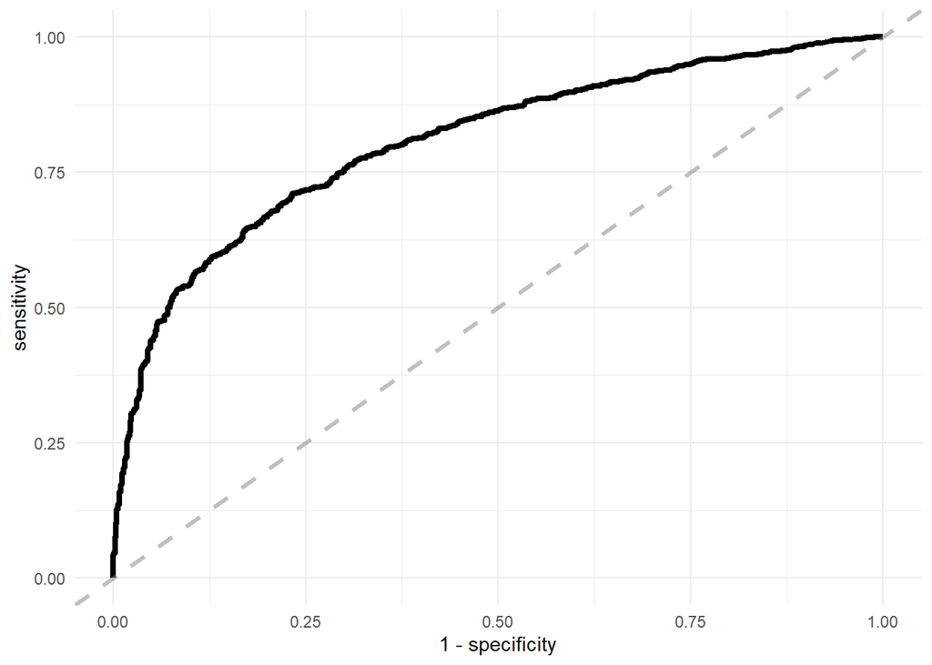

Predict on the test data

```
## tibble [1,151 x 8] (S3: tbl_df/tbl/data.frame)
##  $ Q5d      : Factor w/ 2 levels "0","1": 2 2 1 1 1 1 1 2 1 1 ...
##  $ Q20d     : num [1:1151] NA NA NA NA NA 3 4 3 1 NA ...
##  $ Q16abc   : num [1:1151] NA 6 NA NA NA 9 3 11 0 NA ...
##  $ Q18c     : num [1:1151] NA 2 NA NA NA 3 2 3 1 NA ...
##  $ Q18k     : num [1:1151] NA 2 NA NA NA 4 4 4 1 NA ...
##  $ Q28afghik: num [1:1151] NA NA NA NA NA 23 24 17 11 NA ...
##  $ Q28b     : num [1:1151] NA NA NA NA NA 4 4 4 0 NA ...
##  $ Q28cdej  : num [1:1151] NA NA NA NA NA 13 13 7 0 NA ...
```

```
## # A tibble: 1 x 3
##   .metric .estimator .estimate
##   <chr>   <chr>          <dbl>
## 1 roc_auc binary         0.822
```